# Honework3

Di Zhang 118020518

9/30/2019

## Q2

### (a) What are the weights of each asset in “2012-03”?

```r
library(dplyr)
library(tidyr)
#since BABA started trading after 2014, so the weight of BABA is always 0.
load('/Users/zhangdi/FIN 3380/L2/ret.all.rdata')
crsp.sample=ret.all
crsp.sample=crsp.sample %>% select(permno,date,ret)
crsp.sample=crsp.sample %>% filter(permno!=14888)
crsp.sample.wide=spread (crsp.sample,key=permno,value=ret)
crsp.sample=gather(crsp.sample.wide,key=permno,value=ret,-date)
crsp.sample=crsp.sample %>% mutate(ret=ifelse(is.na(ret),0,ret))
crsp.sample=crsp.sample %>% filter(date>='2012-01-01')
crsp.sample=crsp.sample %>% mutate(date=as.character(date)) %>%
  mutate(yymm=substr(date,1,7)) %>% group_by(permno,yymm) %>%
  mutate(sd=sd(ret)) %>% ungroup()
sd_change=crsp.sample %>% select(permno,yymm,sd) %>%
  group_by(permno,yymm) %>% summarise(sd=first(sd)) %>% mutate(sd=lag(sd,1)) %>%
  filter(!is.na(sd)) %>%
  group_by(yymm) %>% mutate(wgt=(1/sd)/sum(1/sd)) %>% ungroup()
crsp.sample$sd=NULL
crsp.sample=left_join(crsp.sample,sd_change,by=c('permno','yymm')) %>% filter(!is.na(sd))
#the weights of each asset in “2012-03”
sample1=spread(sd_change[,c('permno','yymm','wgt')],permno,wgt)
sample1[,'14888']=0
sample1[which(sample1$yymm=='2012-03'),]
```

```
## # A tibble: 1 x 7
##   yymm    `10107` `11308` `12060` `12490` `14593` `14888`
##   <chr>     <dbl>   <dbl>   <dbl>   <dbl>   <dbl>   <dbl>
## 1 2012-03   0.139   0.282   0.185   0.268   0.126       0
```

### (b) Plot your index performance in year 2013 together with the index performance built based on Equal Weighted and Value-Weighted.

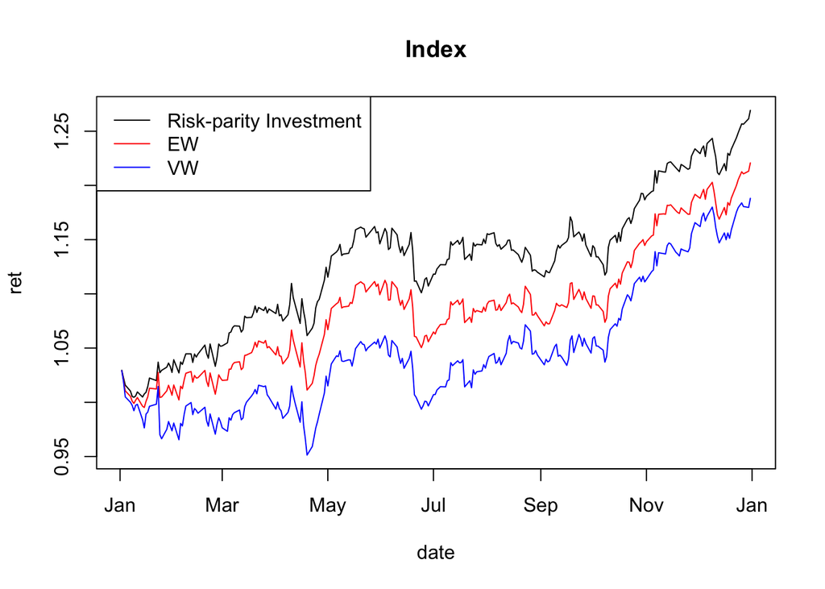

```r
#Risk-parity Investment
crsp.sample=crsp.sample %>% group_by(permno,yymm) %>%
  arrange(date) %>% mutate(cumret=cumprod(ret+1)) %>%
  mutate(pri=cumret*wgt) %>% ungroup()
pri=crsp.sample %>% select(permno,date,yymm,pri)
pri=pri %>% group_by(date) %>%
  summarise(cum=sum(pri),yymm=first(yymm)) %>% filter(date>='2013-01-01' & date<='2013-12-31')
pri=pri %>% group_by(yymm) %>% mutate(ret=cum/lag(cum,1)-1) %>% ungroup() %>%
  mutate(ret=ifelse(is.na(ret),cum-1,ret)) %>%
  arrange(date) %>% mutate(ret=cumprod(ret+1))
#Equal weighted
handle=function(x){
  x=x %>% mutate(date=as.character(date)) %>%
    mutate(yymm=substr(date,1,7)) %>% group_by(permno,yymm) %>%
    arrange(date) %>% mutate(cumret=cumprod(ret+1)) %>% ungroup()
  x.ew=x %>% group_by(date) %>%
    summarise(ew=mean(cumret),yymm=first(yymm)) %>% ungroup()
  x.ew=x.ew %>% group_by(yymm) %>%
    arrange(date) %>% mutate(ret=ew/lag(ew,1)-1) %>% ungroup()
  x.ew=x.ew %>% mutate(ret=ifelse(is.na(ret),ew-1,ret)) %>%
    select(date,ret,yymm)
  return(x.ew)
}
load('/Users/zhangdi/FIN 3380/L2/ret.all.rdata')
crsp.sample=ret.all
crsp.sample=crsp.sample %>% select(permno,date,ret)
crsp.sample=crsp.sample %>% filter(permno!=14888)
crsp.sample.wide=spread (crsp.sample,key=permno,value=ret)
crsp.sample=gather(crsp.sample.wide,key=permno,value=ret,-date)
crsp.sample=crsp.sample %>% mutate(ret=ifelse(is.na(ret),0,ret))
crsp.sample=crsp.sample %>% filter(date>='2012-01-01') %>% select(date,permno,ret)
crsp.sample=handle(crsp.sample)
crsp.sample=crsp.sample %>% filter(date>='2013-01-01' & date<='2013-12-31')
crsp.sample=crsp.sample %>% mutate(cumret=cumprod(ret+1))
eq=crsp.sample
#Value weighted
load('/Users/zhangdi/FIN 3380/L2/six_stocks.RData')
crsp.sample=ret.all
crsp.sample = crsp.sample %>%
  mutate(me=prc*shrout) %>%
  select(permno,date,ret,me) %>%
  mutate(permno=as.character(permno))
crsp.ret = spread(crsp.sample[,c("permno","date","ret")],permno,ret)
crsp.ret = gather(crsp.ret,key=permno,value=ret,-date)
crsp.ret = crsp.ret %>% mutate(ret=ifelse(is.na(ret),0,ret))
crsp.me = crsp.sample %>% select(permno,date,me)
crsp.sample = crsp.ret %>% left_join(crsp.me,by=c("permno","date"))
crsp.vw = crsp.sample %>%
  group_by(permno) %>%
  arrange(date) %>%
  mutate(lag.me=lag(me,1)) %>% ungroup()
crsp.vw = crsp.vw %>%
  mutate(yymm=substr(date,1,7)) %>%
  group_by(permno,yymm) %>%
  arrange(date) %>%
  mutate(lag.me=first(lag.me)) %>% ungroup()
crsp.vw = crsp.vw %>% filter(yymm!=first(yymm))
crsp.vw = crsp.vw %>% mutate(lag.me=ifelse(is.na(lag.me),0,lag.me))
crsp.vw = crsp.vw %>%
  group_by(date) %>%
  mutate(wgt=lag.me/sum(lag.me,na.rm=T)) %>%
  ungroup()
crsp.vw = crsp.vw %>%
  group_by(yymm,permno) %>%
  arrange(date) %>%
  mutate(cumret=cumprod(ret+1)) %>% ungroup()
crsp.vw = crsp.vw %>% arrange(date,permno)
crsp.vw = crsp.vw %>%
  mutate(vw=wgt*cumret)
crsp.vw = crsp.vw %>%
  group_by(date) %>%
  summarise(vw=sum(vw),yymm=first(yymm)) %>% ungroup()
crsp.vw=crsp.vw %>% group_by(yymm) %>% arrange(date) %>% mutate(ret=vw/lag(vw,1)-1) %>% ungroup()
crsp.vw.2013 = crsp.vw %>% filter(date>='2013-01-01' & date<='2013-12-31')
crsp.vw.2013=crsp.vw.2013 %>% arrange(date) %>% mutate(ret=ifelse(is.na(ret),vw-1,ret))%>% mutate(vw=cumprod(ret+1))
#in the same chart
yrange=range(c(pri$ret,eq$cumret,crsp.vw.2013$vw))
plot(pri$ret~as.Date(pri$date),type='l',ylab='ret',xlab='date',main='Index',ylim=yrange)
lines(eq$cumret~as.Date(eq$date),col='red')
lines(crsp.vw.2013$vw~as.Date(crsp.vw.2013$date),col='blue')
legend("topleft",c("Risk-parity Investment","EW","VW"),col=c("black","red","blue"),lty=c(1,1,1))
```

## Q3

### (a) Write the variance of the portfolio with 6 stocks as a function of these 6 stocks’ weights (denoted as w1,w2,…, w6), variances (denoted as σ21,σ22,…, σ26) and covariances (denoted as σ1,2,σ1,3,…,σ5,6).

$\sigma_{p}^2=w_{1}^2\sigma_{1}^2+w_{2}^2\sigma_{2}^2+w_{3}^2\sigma_{3}^2+w_{4}^2\sigma_{4}^2+w_{5}^2\sigma_{5}^2+w_{6}^2\sigma_{6}^2+2w_{ 1 }w_{ 2 }\sigma_{ 1 , 2 }+2w_{ 1 }w_{ 3 }\sigma_{ 1 , 3 }+2w_{ 1 }w_{ 4 }\sigma_{ 1,4 }+2w_{ 1 }w_{ 5 }\sigma_{ 1 , 5 }+2w_{ 1 }w_{ 6 }\sigma_{ 1 , 6 }$ $+2w_{ 2 }w_{ 3 }\sigma_{ 2 , 3 }+2w_{ 2 }w_{ 4 }\sigma_{ 2 , 4 }+2w_{ 2 }w_{ 5 }\sigma_{ 2 , 5 }+2w_{ 2 }w_{ 6 }\sigma_{ 2 , 6 }++2w_{ 3 }w_{ 4 }\sigma_{ 3 , 4 }+2w_{ 3 }w_{ 5 }\sigma_{ 3 , 5 }+2w_{ 3 }w_{ 6 }\sigma_{ 3 , 6 }+2w_{ 4 }w_{ 5 }\sigma_{ 4 , 5 }+2w_{ 4 }w_{ 6 }\sigma_{ 4 , 6 }+2w_{ 5 }w_{ 6 }\sigma_{ 5 , 6 }$

### (b) Calculate the variance of your portfolio using the function you write and calculate the variance using the matrix format.

#### 1) Using the function wrote

```r
load('/Users/zhangdi/FIN 3380/L2/ret.all.rdata')
wgt.all=data.frame(ticker=c("AAPL","MSFT","IBM","BABA","GE","KO"),wgt=c(0.1,0.2,0.15,0.25,0.1,0.2))
tickers=data.frame(ticker=c("AAPL","BABA","GE","IBM","KO","MSFT"),permno=c(14593,14888,12060,12490,11308,10107))
ret.all = merge(ret.all,tickers,by.x="permno",by.y="permno",all.x=T, all.y = T)
ret.all = ret.all %>% select(-permno)
ret.all = spread(ret.all,"ticker","ret")
ret.all = ret.all[complete.cases(ret.all),]
cov.m = cov(ret.all[,2:ncol(ret.all)])
cov.m = cov.m * 252
print(cov.m)
```

```
##             AAPL        BABA          GE        IBM          KO       MSFT
## AAPL 0.059040698 0.029098268 0.017445939 0.01872751 0.008506402 0.03263340
## BABA 0.029098268 0.104402687 0.015798795 0.01868988 0.007010843 0.03337373
## GE   0.017445939 0.015798795 0.066615227 0.02000346 0.007289161 0.01876937
## IBM  0.018727514 0.018689882 0.020003463 0.04262820 0.010088155 0.02312196
## KO   0.008506402 0.007010843 0.007289161 0.01008816 0.019077253 0.01164531
## MSFT 0.032633398 0.033373726 0.018769374 0.02312196 0.011645311 0.05721511
```

```r
wgt.all = wgt.all[order(wgt.all$ticker),]
print(wgt.all)
```

```
##   ticker  wgt
## 1   AAPL 0.10
## 4   BABA 0.25
## 5     GE 0.10
## 3    IBM 0.15
## 6     KO 0.20
## 2   MSFT 0.20
```

```r
sigma_p=0
for(i in 1:6){
  for (j in 1:6){
    sigma_p=sigma_p+wgt.all$wgt[i]*wgt.all$wgt[j]*cov.m[i,j]
  }
}
cat('The variance using function formula is ',sigma_p)
```

```
## The variance using function formula is  0.02660062
```

#### 2) Using matrix format

```r
wgt=matrix(wgt.all$wgt,1)
sigma_p=wgt %*% cov.m %*% t(wgt)
cat('The variance using matrix formula is ',sigma_p)
```

```
## The variance using matrix formula is  0.02660062
```

## Q4

### load the data and check

```r
load('/Users/zhangdi/FIN 3380/Homework/HW3/crsp.sample.rdata')
crsp.sample=crsp.sample %>% filter(permno==39731 | permno==79089 | permno==83148) %>%
  arrange(date) %>% filter(date>='2017-01-01' & date<='2018-12-31')
crsp.sample$prc=ifelse(crsp.sample$prc<0,-crsp.sample$prc,crsp.sample$prc)
tmp.summary = crsp.sample %>% group_by(permno) %>% summarise(n=n())
summary(crsp.sample)
```

```
##      permno           date                 ret                  prc
##  Min.   :39731   Min.   :2017-01-03   Min.   :-0.2508446   Min.   : 5.67
##  1st Qu.:39731   1st Qu.:2017-07-03   1st Qu.:-0.0144242   1st Qu.:12.01
##  Median :79089   Median :2017-12-31   Median : 0.0000000   Median :13.20
##  Mean   :67323   Mean   :2017-12-31   Mean   : 0.0004232   Mean   :14.10
##  3rd Qu.:83148   3rd Qu.:2018-07-02   3rd Qu.: 0.0147399   3rd Qu.:14.92
##  Max.   :83148   Max.   :2018-12-31   Max.   : 0.8772123   Max.   :31.14
##      shrout
##  Min.   : 6405
##  1st Qu.: 6729
##  Median :27534
##  Mean   :27646
##  3rd Qu.:48511
##  Max.   :49456
```

```r
tmp.summary
```

```
## # A tibble: 3 x 2
##   permno     n
##    <dbl> <int>
## 1  39731   502
## 2  79089   502
## 3  83148   502
```

### (a) Calculate their daily average return, standard deviation, covariance and correlation.

```r
#daily average return
daily_return=crsp.sample %>% select(permno,date,ret) %>% group_by(permno) %>%
  arrange(date) %>% summarise(average_return=mean(ret))
print(daily_return)
```

```
## # A tibble: 3 x 2
##   permno average_return
##    <dbl>          <dbl>
## 1  39731       0.000870
## 2  79089       0.000507
## 3  83148      -0.000107
```

```r
#daily standard deviation
sd=crsp.sample %>% select(permno,date,ret) %>% group_by(permno) %>%
  arrange(date) %>% summarise(standard_deviation=sd(ret))
print(sd)
```

```
## # A tibble: 3 x 2
##   permno standard_deviation
##    <dbl>              <dbl>
## 1  39731             0.0275
## 2  79089             0.0591
## 3  83148             0.0199
```

```r
#daily covariance
covariance=crsp.sample %>% select(permno,date,ret)
covariance=spread(covariance,permno,ret) %>% arrange(date)
covariance=cov(covariance[,2:4])
cat('The covariance of 39731 and 79089 is ',covariance[1,2],'.The covariance of 39731 and 83148 is ',covariance[1,3],'.The covariance of 79089 and 83148 is ',covariance[2,3],'.','\n')
```

```
## The covariance of 39731 and 79089 is  6.842361e-05 .The covariance of 39731 and 83148 is  6.452474e-05 .The covariance of 79089 and 83148 is  0.0001670901 .
```

```r
#daily correlation
correlation=crsp.sample %>% select(permno,date,ret)
correlation=spread(correlation,permno,ret) %>% arrange(date)
correlation=cor(correlation[,2:4])
cat('The correlation of 39731 and 79089 is ',correlation[1,2],'.The correlation of 39731 and 83148 is ',correlation[1,3],'.The correlation of 79089 and 83148 is ',correlation[2,3],'.','\n')
```

```
## The correlation of 39731 and 79089 is  0.0421744 .The correlation of 39731 and 83148 is  0.1179101 .The correlation of 79089 and 83148 is  0.1419266 .
```

### (b) Annualize the results in a assuming in each year, there are 252 days.

```r
#annualize return
daily_return$average_return=daily_return$average_return*252
print(daily_return)
```

```
## # A tibble: 3 x 2
##   permno average_return
##    <dbl>          <dbl>
## 1  39731         0.219
## 2  79089         0.128
## 3  83148        -0.0271
```

```r
#annualize standard deviation
sd$standard_deviation=sd$standard_deviation*sqrt(252)
print(sd)
```

```
## # A tibble: 3 x 2
##   permno standard_deviation
##    <dbl>              <dbl>
## 1  39731              0.436
## 2  79089              0.938
## 3  83148              0.316
```

```r
#annualize covariance
covariance=covariance*252
cat('The covariance of 39731 and 79089 is ',covariance[1,2],'.The covariance of 39731 and 83148 is ',covariance[1,3],'.The covariance of 79089 and 83148 is ',covariance[2,3],'.','\n')
```

```
## The covariance of 39731 and 79089 is  0.01724275 .The covariance of 39731 and 83148 is  0.01626023 .The covariance of 79089 and 83148 is  0.0421067 .
```

```r
#annualize correlation
cat('The correlation of 39731 and 79089 is ',correlation[1,2],'.The correlation of 39731 and 83148 is ',correlation[1,3],'.The correlation of 79089 and 83148 is ',correlation[2,3],'.','\n')
```

```
## The correlation of 39731 and 79089 is  0.0421744 .The correlation of 39731 and 83148 is  0.1179101 .The correlation of 79089 and 83148 is  0.1419266 .
```

### (c) Calculate your portfolio annulized standard deviation and annulized average return, Present your result for the following weights combindation: weights (39731,79089,83148)=(0.4,0.2,0.4) and weights(39731,79089,83148)=c(0.8,0.1,0.1).

```r
ef=data.frame()
x=0
for (i in seq(0,1,0.01)){
  y=1-i
  for (j in seq(0,y,0.01)){
    x=x+1
    c=1-i-j
    ef[x,1]=i
    ef[x,2]=j
    ef[x,3]=c
  }
}
ef[,3]=round(ef[,3],2)
names(ef)=c('wgt.39731','wgt.79089','wgt.83148')
#annualized average return using their returns
ef=ef %>% mutate(annualized_return=wgt.39731*daily_return$average_return[1]+wgt.79089*daily_return$average_return[2]+wgt.83148*daily_return$average_return[3])
#annualized portfolio standard deviation
ef=ef %>% mutate(var=wgt.39731*wgt.39731*covariance[1,1]+wgt.79089*wgt.79089*covariance[2,2]+wgt.83148*wgt.83148*covariance[3,3]+2*wgt.39731*wgt.79089*covariance[1,2]+2*wgt.39731*wgt.83148*covariance[1,3]+2*wgt.79089*wgt.83148*covariance[2,3])
ef=ef %>% mutate(sd=sqrt(var))
ef$var=NULL
#weights combindation: weights (39731,79089,83148)=(0.4,0.2,0.4)
sample1=ef %>% filter(wgt.39731==0.4 & wgt.79089==0.2 &wgt.83148==0.4)
print(sample1)
```

```
##   wgt.39731 wgt.79089 wgt.83148 annualized_return        sd
## 1       0.4       0.2       0.4         0.1024468 0.3103218
```

```r
#weights combindation: weights (39731,79089,83148)=(0.8,0.1,0.1)
sample1=ef %>% filter(wgt.39731==0.8 & wgt.79089==0.1 &wgt.83148==0.1)
print(sample1)
```

```
##   wgt.39731 wgt.79089 wgt.83148 annualized_return        sd
## 1       0.8       0.1       0.1         0.1855511 0.3709782
```

### (d) Round the standard deviation and average return to 3 digits for each portfolio, and construct the efficient frontier using the rounded results. Plot your efficient frontier from these three assets.

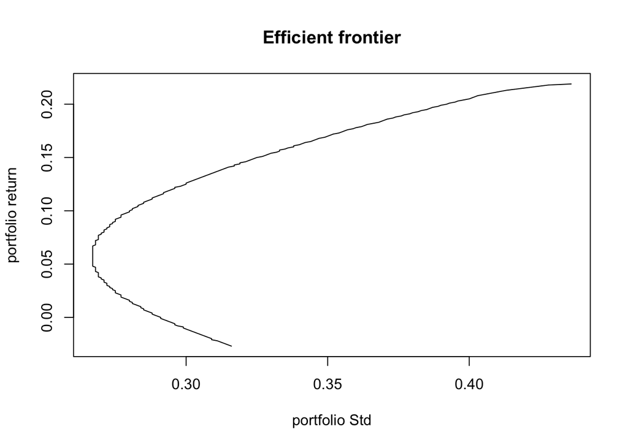

```r
ef$annualized_return=round(ef$annualized_return,3)
ef$sd=round(ef$sd,3)
ef_sum=ef %>% select(annualized_return,sd) %>% group_by(annualized_return) %>%
  summarise(sd=min(sd))
plot(ef_sum$annualized_return~ef_sum$sd,type='l',ylab='portfolio return',xlab='portfolio Std',main='Efficient frontier')
```

### (e) Assuming the risk free rate is 0. What is the portfolio allocation that gives you the highest sharpe ratio?

```r
ef=ef %>% mutate(sr=annualized_return/sd)
allocation=ef[which(ef$sr==max(ef$sr)),]
print(allocation)
```

```
##      wgt.39731 wgt.79089 wgt.83148 annualized_return    sd       sr
## 5084      0.89       0.1      0.01             0.208 0.403 0.516129
```